# challenge_Piervincenzo_Ventrella

### Decision Trees:

Is interestinng to try decision trees algorithms because:

- they are able to capture non-linear relationships between input features and target;
- they can deal with highly correlated features;
- they perform feature selection selecting the best feature to use in a branch-node thanks to the 'information gain' criterion.

```python
from sklearn import tree
```

```python
train_MSE = []
test_MSE = []
train_r2 = []
test_r2 = []
max_depth = [1,3,5,7,10,12,15,17,20,25,30,35,40]
```

```python
for max_d in max_depth:
    reg = tree.DecisionTreeRegressor(max_depth=max_d)
    result = crossValidate(reg, False)
    train_MSE.append(result['train_MSE'])
    test_MSE.append(result['test_MSE'])
    train_r2.append(result['train_r2'])
    test_r2.append(result['test_r2'])
```

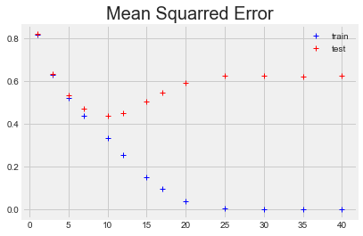

```python
plt.plot(max_depth, train_MSE,'b+')
plt.plot(max_depth, test_MSE,'r+' )
plt.legend(['train', 'test'], loc='upper right')
plt.title('Mean Squarred Error', fontsize=20)
plt.show()
```

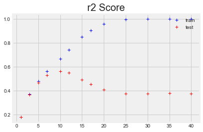

```python
plt.plot(max_depth, train_r2,'b+')
plt.plot(max_depth, test_r2,'r+' )
plt.legend(['train', 'test'], loc='upper right')
plt.title('r2 Score', fontsize=20)
plt.show()
```

We can notice that:

- decision trees perform much better than the previous algorithms (even better than Lasso);
- when we increase too much the depth of the trees (max_depth > 10) the model overfits;

##### Analyze tree with best max_depth:

```python
best_depth = 10
reg = tree.DecisionTreeRegressor(max_depth=best_depth)
result = crossValidate(reg, True)
```

```
DecisionTreeRegressor(criterion='mse', max_depth=10, max_features=None,
                      max_leaf_nodes=None, min_impurity_decrease=0.0,
                      min_impurity_split=None, min_samples_leaf=1,
                      min_samples_split=2, min_weight_fraction_leaf=0.0,
                      presort=False, random_state=None, splitter='best')

training time: 0.19
prediction time: 0.0

train_mean_squared_error : 0.33379
average test mean_squared_error : 0.43943

train_r2_score : 0.666
average test_r2: 0.561
```

```python
#keep track of performance
algoirthms_name.append("Decision Tree")
best_hyperparameter.append("max_depth = 10")
train_MSE_results.append(result['train_MSE'])
test_MSE_results.append(result['test_MSE'])
train_r2_results.append(result['train_r2'])
test_r2_results.append(result['test_r2'])
```

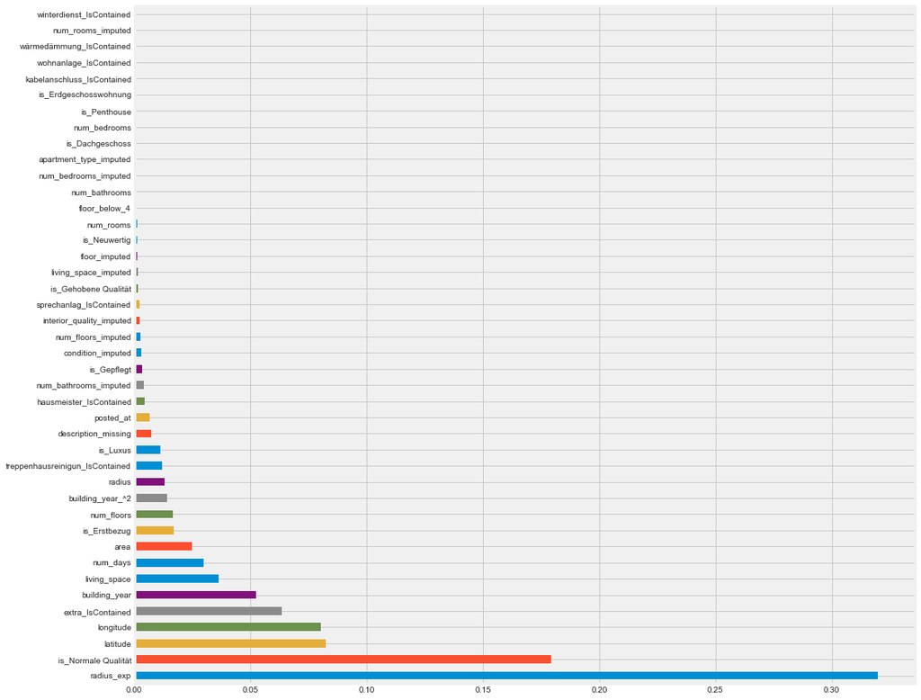

```python
features_ordered_by_importance = []
importances = result['predictor'].feature_importances_

indices = np.argsort(importances)[::-1]
values_ordered_by_importance = []


for f in range(len(FEATURES)):
    #print("%d.  %s (%f)" % (f + 1, name_mapping_dictionary[FEATURES[indices[f]]], importances[indices[f]]))
    features_ordered_by_importance.append(FEATURES[indices[f]])
    values_ordered_by_importance.append(importances[indices[f]])

(pd.Series(values_ordered_by_importance, index=features_ordered_by_importance)
   .plot(kind='barh', figsize = (15,15)))
```

From the plot above we can easily check which are the most important features (and which are not) according to the decision tree algorithm.  
How we noticed before, the problem of single decision trees is that they tend to overfitt when we increase the depth.  
For this purpose we can try to use ensemble methods (i.e. Random Forest) that thanks to averaging voting they should reduce overfitting and increase the performance.

### Random Forest

```python
from sklearn.ensemble import RandomForestRegressor
```

```python
train_MSE = []
test_MSE = []
train_r2 = []
test_r2 = []
num_estimators = [1,5,10,20,40,80,150,200]
```

```python
#we fix the max_depth of the trees and check the performance when the number of estimators increases
for n in num_estimators:
    reg = RandomForestRegressor(random_state=1, n_estimators=n, max_depth=20)
    result = crossValidate(reg, False)
    train_MSE.append(result['train_MSE'])
    test_MSE.append(result['test_MSE'])
    train_r2.append(result['train_r2'])
    test_r2.append(result['test_r2'])
```

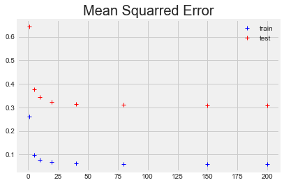

```python
plt.plot(num_estimators, train_MSE,'b+')
plt.plot(num_estimators, test_MSE,'r+' )
plt.legend(['train', 'test'], loc='upper right')
plt.title('Mean Squarred Error', fontsize=20)
plt.show()
```

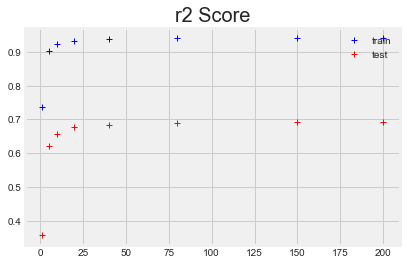

```python
plt.plot(num_estimators, train_r2,'b+')
plt.plot(num_estimators, test_r2,'r+' )
plt.legend(['train', 'test'], loc='upper right')
plt.title('r2 Score', fontsize=20)
plt.show()
```

##### Analyze RF with best number of estimators:

```python
best_num_estimators = 75
reg = RandomForestRegressor(random_state=1, n_estimators=best_num_estimators, max_depth=20)
result = crossValidate(reg, True)
```

```
RandomForestRegressor(bootstrap=True, criterion='mse', max_depth=20,
                      max_features='auto', max_leaf_nodes=None,
                      min_impurity_decrease=0.0, min_impurity_split=None,
                      min_samples_leaf=1, min_samples_split=2,
                      min_weight_fraction_leaf=0.0, n_estimators=75,
                      n_jobs=None, oob_score=False, random_state=1, verbose=0,
                      warm_start=False)

training time: 13.66
prediction time: 0.09

train_mean_squared_error : 0.05953
average test mean_squared_error : 0.31122

train_r2_score : 0.94
average test_r2: 0.689
```

```python
#keep track of performance
algoirthms_name.append("Random Forest")
best_hyperparameter.append("num_estimators = 75")
train_MSE_results.append(result['train_MSE'])
test_MSE_results.append(result['test_MSE'])
train_r2_results.append(result['train_r2'])
test_r2_results.append(result['test_r2'])
```

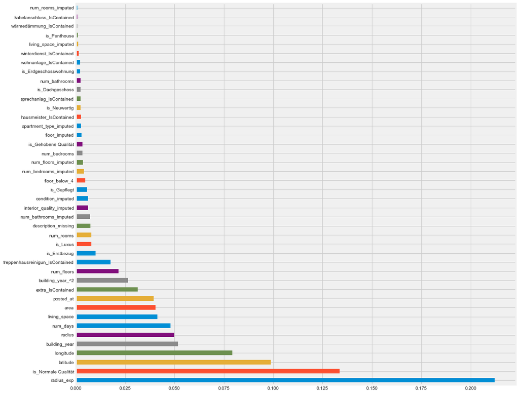

```python
features_ordered_by_importance = []
importances = result['predictor'].feature_importances_

indices = np.argsort(importances)[::-1]
values_ordered_by_importance = []


for f in range(len(FEATURES)):
    #print("%d.  %s (%f)" % (f + 1, name_mapping_dictionary[FEATURES[indices[f]]], importances[indices[f]]))
    features_ordered_by_importance.append(FEATURES[indices[f]])
    values_ordered_by_importance.append(importances[indices[f]])

(pd.Series(values_ordered_by_importance, index=features_ordered_by_importance)
   .plot(kind='barh', figsize = (15,15)))
```

### Simple Neural Network - Multi layer Perceptron

We experiment a little bit with a Multi Layer Perceptron architecture.  
We just try to tune the hyperparameter hidden_layer_size but we could do much more (i.e. trying different solvers, activation functions, learning rate, etc.).

```python
from sklearn.neural_network import MLPRegressor
```

```python
train_MSE = []
test_MSE = []
train_r2 = []
test_r2 = []
hidden_layer_sizes = [1, 3 ,5 ,10,20,30,50,75,100]
```

```python
for size in hidden_layer_sizes:
    reg = MLPRegressor(hidden_layer_sizes=(size,),
                       activation='tanh', solver='adam',
                       alpha=0.0001, batch_size='auto', learning_rate='constant',
                       learning_rate_init=0.001, power_t=0.5, max_iter=1000, shuffle=True,
                       random_state=None, tol=0.0001, verbose=False, warm_start=False, momentum=0.9,
                       nesterovs_momentum=True, early_stopping=True,)
    result = crossValidate(reg, False)
    train_MSE.append(result['train_MSE'])
    test_MSE.append(result['test_MSE'])
    train_r2.append(result['train_r2'])
    test_r2.append(result['test_r2'])
```

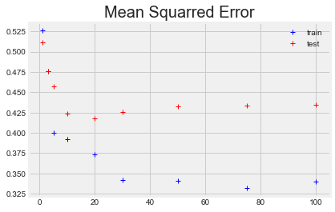

```python
#sizes = [10,20,30,50,75,100]
plt.plot(hidden_layer_sizes, train_MSE,'b+')
plt.plot(hidden_layer_sizes, test_MSE,'r+' )
plt.legend(['train', 'test'], loc='upper right')
plt.title('Mean Squarred Error', fontsize=20)
plt.show()
```

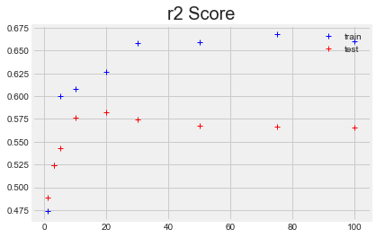

```python
plt.plot(hidden_layer_sizes, train_r2,'b+')
plt.plot(hidden_layer_sizes, test_r2,'r+' )
plt.legend(['train', 'test'], loc='upper right')
plt.title('r2 Score', fontsize=20)
plt.show()
```

##### Analyze NN with best hidden_layer size:

```python
best_size = (20,)
reg = MLPRegressor(hidden_layer_sizes=best_size,
                       activation='tanh', solver='adam',
                       alpha=0.0001, batch_size='auto', learning_rate='constant',
                       learning_rate_init=0.001, power_t=0.5, max_iter=200, shuffle=True,
                       random_state=None, tol=0.0001, verbose=False, warm_start=False, momentum=0.9,
                       nesterovs_momentum=True, early_stopping=True,)
result = crossValidate(reg, True)
```

```
MLPRegressor(activation='tanh', alpha=0.0001, batch_size='auto', beta_1=0.9,
             beta_2=0.999, early_stopping=True, epsilon=1e-08,
             hidden_layer_sizes=(20,), learning_rate='constant',
             learning_rate_init=0.001, max_iter=200, momentum=0.9,
             n_iter_no_change=10, nesterovs_momentum=True, power_t=0.5,
             random_state=None, shuffle=True, solver='adam', tol=0.0001,
             validation_fraction=0.1, verbose=False, warm_start=False)

training time: 5.53
prediction time: 0.0

train_mean_squared_error : 0.40608
average test mean_squared_error : 0.4247

train_r2_score : 0.594
average test_r2: 0.575
```

```python
#keep track of performance
algoirthms_name.append("Multi Layer Perceptron")
best_hyperparameter.append("hidden_layer_size = 20")
train_MSE_results.append(result['train_MSE'])
test_MSE_results.append(result['test_MSE'])
train_r2_results.append(result['train_r2'])
test_r2_results.append(result['test_r2'])
```

Unfortunately. the Multi-Layer Perceptron does not have an intrinsic feature importance, such as Decision Trees and Random Forests do. Neural Networks rely on complex co-adaptations of weights during the training phase instead of measuring and comparing quality of splits.

### 2.4 Select best model

```python
#create dataframe with the tracked performance
report = {'Algorithm': algoirthms_name, 'Best Hyperparameter value': best_hyperparameter,'train_MSE': train_MSE_results,
          'test_MSE': test_MSE_results,'train_r2_score': train_r2_results, 'test_r2_score': test_r2_results}
report = pd.DataFrame(data=report)
report.head()
```

|  | Algorithm | Best Hyperparameter value | train_MSE | test_MSE | train_r2_score | test_r2_score |
| --- | --- | --- | --- | --- | --- | --- |
| 0 | Lasso | alpha = 0.025 | 0.615389 | 0.619274 | 0.384611 | 0.380736 |
| 1 | Decision Tree | max_depth = 10 | 0.333786 | 0.439428 | 0.666214 | 0.560629 |
| 2 | Random Forest | num_estimators = 75 | 0.059528 | 0.311218 | 0.940472 | 0.688856 |
| 3 | Multi Layer Perceptron | hidden_layer_size = 20 | 0.406082 | 0.424701 | 0.593918 | 0.575343 |

How we can notice, the best performing model (both in terms of test_MSE and test_r2_score) is the Random Forest algorithm with num_estimators = 75.

- test_MSE = 0.311218
- test_r2_score = 0.688856

These performance are actually computed with crossvalidation (therefore is better to say validation_MSE and validation_r2_score).  
Let's check now, after picking the best model, how it actually perform with the test that we NEVER saw before.

```python
#compute metrics on the real test set
final_model = RandomForestRegressor(random_state=1, n_estimators=75, max_depth=20)
final_model.fit(train[FEATURES], train[LOG_TARGET])

test_predictions = final_model.predict(test[FEATURES])
test_r2 = m.r2_score(test[LOG_TARGET], test_predictions)
test_mean_squared_error = m.mean_squared_error(test[LOG_TARGET], test_predictions)

print("test_mean_squared_error : " + str(round(test_mean_squared_error,5)))
print()

print("test_r2_score : " + str(round(test_r2,3)))
```

```
test_mean_squared_error : 0.32144

test_r2_score : 0.671
```

Ok, the performance are similar to the one obtained with crossvalidation, this means that we did not overfit.  
Let's try to plot LOG_TARGET with respect to the predictions: ideally there should be a line LOG_TARGET = predictions.

```python
#create dataframe with test_predictions
predictions = {'Prediction': test_predictions}
predictions = pd.DataFrame(data=predictions)
```

```python
#concatenate to original test set
test = pd.concat([test,predictions],axis=1)
```

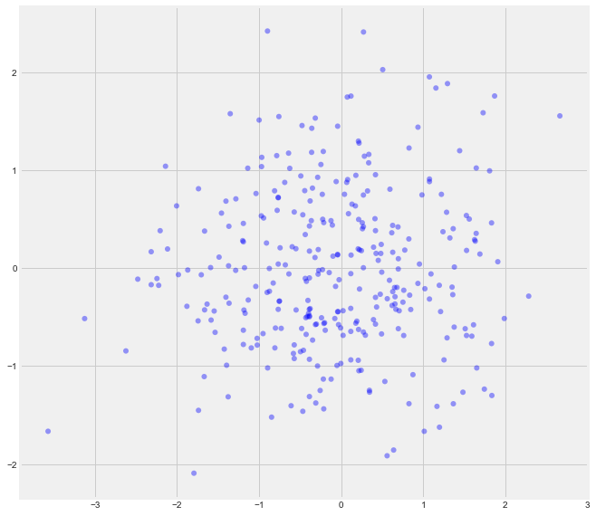

```python
#let's take a subsample of the training set (faster computation and more easy to visualize)
test_sample = test.sample(frac=0.1, random_state=1234).reset_index(drop=True)
fig, ax = matplotlib.pyplot.subplots(figsize=(10,10))
for index, row in test_sample.iterrows():
    x = row[LOG_TARGET]
    #print(type(x))
    y = row['Prediction']
    color = 'blue'
    label = 'normal'


    ax.scatter(x, y, c=color,
               alpha=0.4, edgecolors='none')

matplotlib.pyplot.show()
```

Ok, it is evident that this scatter plot does not show a relation LOG_TARGET = predictions.  
This means that we could do better but for now we stop.

As last step, let's just check if the prediction errors follow a normal distibution:

```python
test['error'] = test.apply(lambda x : (x[LOG_TARGET]*100 - x['Prediction']*100),axis=1)
```

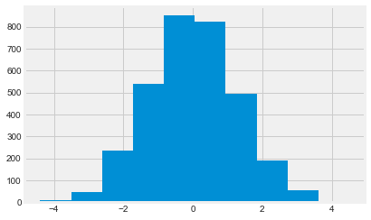

```python
test['error'].hist()
```

It seems to follow a normal distribution (the model is not biased).

### 2.5 Future work

As we stated before, we tried just few of the available regression algorithms but we should experiment with more of them.  
For example we just used an example of ensemble (Random Forest) but we should try out also other of them that works differently (see GradientTreeBosting, Adaboost, etc.).  
What about KNN, SVM, Naive Bayes, etc? We should try them as well.  
We saw how some algorithms is not able to learn and completely overfitt.  
Therefore, another important thing that we should do is to try different subsets of features (what about removing the features in SHOULD_REMOVE list or considering only the most important binary features?!) and apply feature selection.  
We saw some intrinsic feature selection procedure (l1 penalization with Lasso and information gain with Decision Trees) but there are other possible approaches (see PCA, backward or forward feature selection. etc.).  
That's all for now!  
Best,  
Piervincenzo Ventrella (piervincenzov@gmail.com).